# Data Visualization for Education

## SDP Fellow Workshop January 2013

Jared Knowles  
Policy Research Advisor, Wisconsin DPI

## Objectives

1. Review data visualization principles
2. Look at applications in education data
3. Challenges in an LEA/SEA
4. Best practices and advice
5. What tools to use

## Example

```r
qplot(hp, mpg, data = mtcars) + theme_dpi()
```

[figure not shown]

## Principles

- Elements of a chart
- Chart Types and Data Types
- Dimensionality
- Scale
- Complexity
- Technical details
- Beyond charts

[figure not shown]

## Chart Elements

There are a few things that all charts need. There are sometimes strong cases to deviate from these, but they are good rules of thumb.

- Axis labels and a chart title
  - These make the chart self-explanatory
- A legend
  - What is the unit in the graphic?
- A scale
  - How are units mapped to the visual space
- Annotations
  - Author and data source (depending on distribution)

## Data Types

### Statistics we can use

| Level of Meas. | Stats |
| --- | --- |
| Nominal | mode, Chi-squared |
| Ordinal | median, percentile |
| Interval | mean, std. deviation, correlation, ANOVA |
| Continuous | geometric mean, harmonic mean, logarithms |

### Aesthetics for Mapping

| Aesthetic | Discrete | Continuous |
| --- | --- | --- |
| Color | Disparate colors | Sequential or divergent colors |
| Size | Unique size for each value | mapping to radius of value |
| Shape | A shape for each value | **does not make sense** |

## Ordered vs. Unordered

### Mapping Possibilities

| Aesthetic | Ordered | Unordered |
| --- | --- | --- |
| Color | Sequential or divergent colors | Rainbow |
| Size | Increasing or decreasing radius | **does not make sense** |
| Shape | **does not make sense** | A shape for each value |

## Example

[figure not shown]

## Arbitrary image

Think like a map. Data density and easy interpretability.

## Some tips

- Focus on the content
- Use best practices
- Understand the limitations
- Experiment and iterate!

## Charting Data

- The type of data we look at determines the way it should be presented
- It always starts with the data
- Let's review the data types
- Categorical
- Ordinal
- Interval
- Continuous

## Charting Categorical Data

[figure not shown]

## Conditional 2

[figure not shown]

## Some tips

- Have a properly chosen format and design
- Use words, numbers and drawing together
- Reflect a balance, a proportion, relevant scale
- Display an accessible complexity of details
- Have a narrative quality, tell a story
- Avoid content-free decoration (Tufte's proverbial chartjunk)
- Draw in a professional manner with an eye on the technical details
- Remember the map

## Themes convey brands

```r
qplot(hp, mpg, data = mtcars) + theme_economist()
```

[figure not shown]

## They Also Communicate

```r
qplot(hp, mpg, data = mtcars) + theme_tufte()
```

[figure not shown]

## They Also Can Confound

```r
qplot(hp, mpg, data = mtcars, color = factor(cyl)) + theme_excel2003() + scale_color_excel2003()
```

[figure not shown]

## So Choose Wisely

```r
qplot(hp, mpg, data = mtcars, color = factor(cyl)) + theme_stata()
```

[figure not shown]

## Stacked Bar

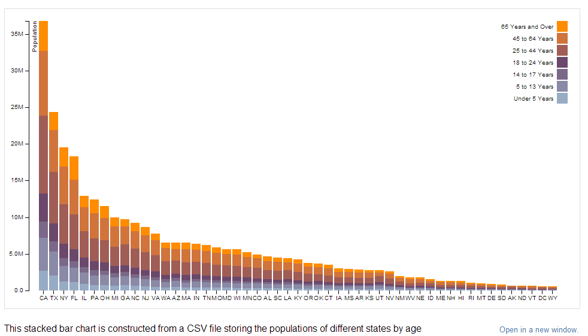

## Box and Whisker

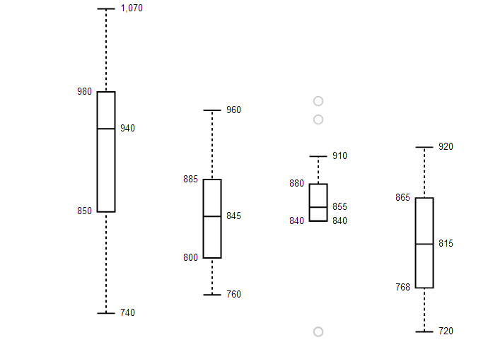

## Bullet Chart

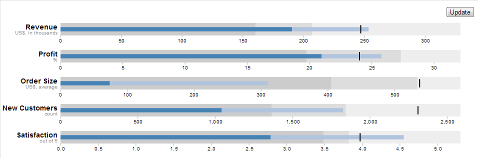

## Calendar

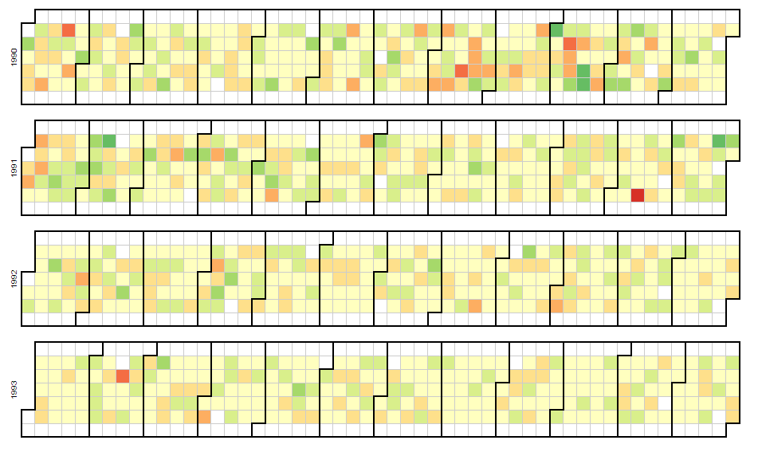

## Lines

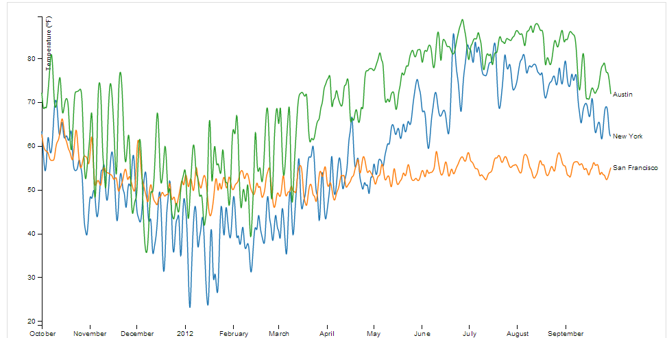

## Parallel Coordinates

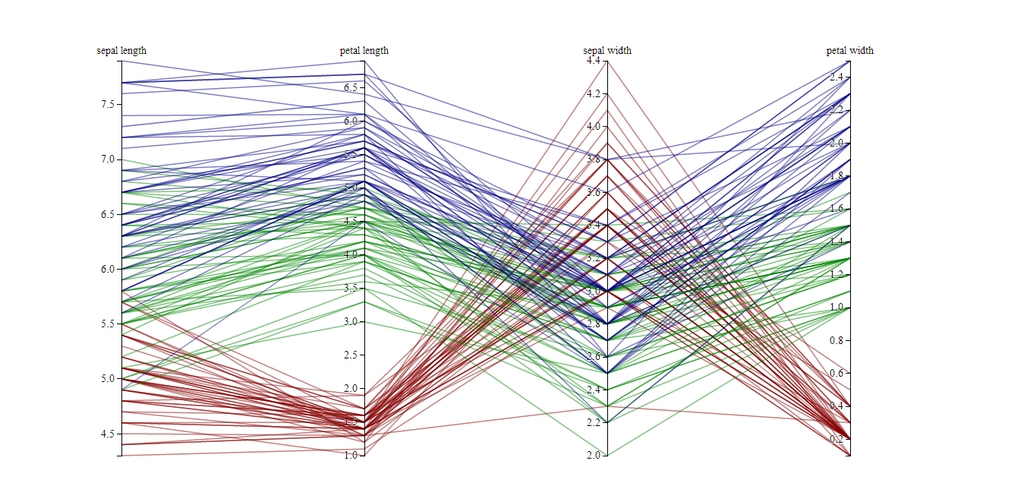

## Parallel Sets

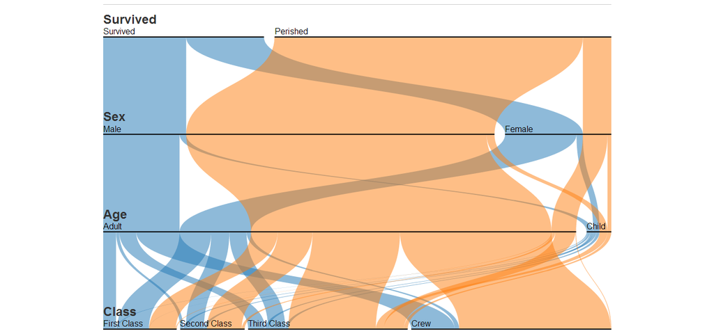

## Streamgraph

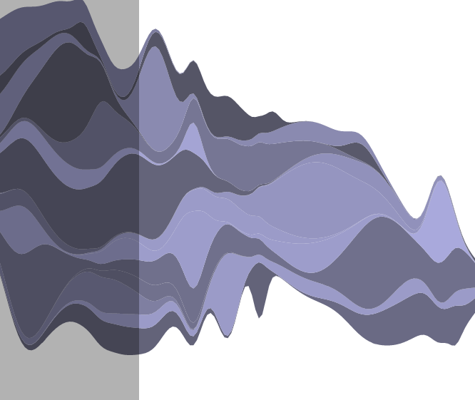

## Tree Map

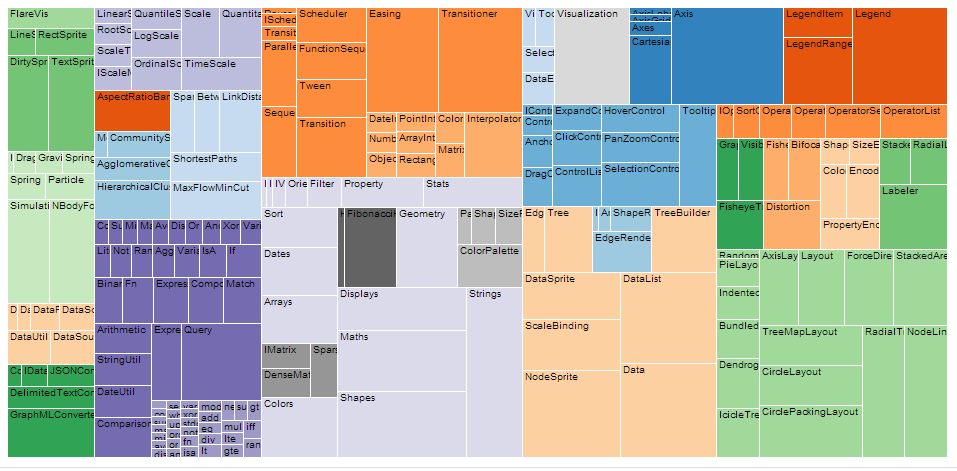

## Word Cloud

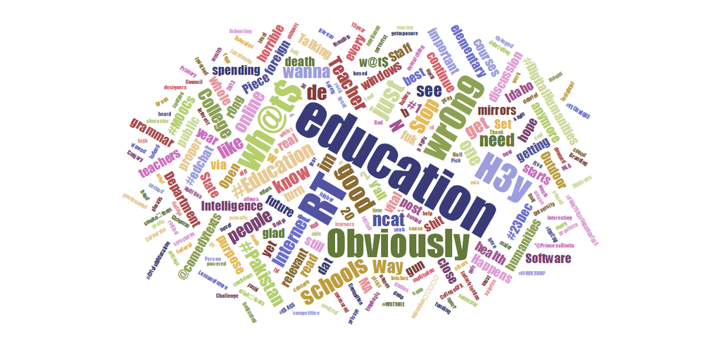

## Graphics Types

### Raster

- Files like **jpg** , **png** , **gif**.
- Fixed scale, aspect ratio, and size
- Reasonable file size
- Viewable in almost any image viewing and editing system, including any modern web browser, PowerPoint, etc.

### Vector

- Files like **pdf** and **svg**
- Infinitely zoomable, adjustable on the fly
- Larger file size
- Viewable and usable in fewer systems. SVGs can be used in modern web browsers. PDFs included in other PDF reports.

## Ugly graphic

[interactive chart not shown]

## Backmatter

```
R version 2.15.2 (2012-10-26)
Platform: x86_64-w64-mingw32/x64 (64-bit)

attached base packages:
[1] grid      stats     graphics  grDevices utils     datasets  methods
[8] base

other attached packages:
 [1] vcd_1.2-13       colorspace_1.2-0 MASS_7.3-22      ggthemes_1.1.0
 [5] eeptools_0.1     mapproj_1.1-8.3  maps_2.2-8       proto_0.3-9.2
 [9] plyr_1.8         ggplot2_0.9.3    stringr_0.6.2    knitr_0.9
[13] markdown_0.5.3   whisker_0.1      slidify_0.3.3    devtools_0.8

loaded via a namespace (and not attached):
 [1] dichromat_1.2-4    digest_0.6.0       evaluate_0.4.3
 [4] formatR_0.7        gtable_0.1.2       httr_0.2
 [7] labeling_0.1       memoise_0.1        munsell_0.4
[10] parallel_2.15.2    RColorBrewer_1.0-5 RCurl_1.95-3
[13] reshape2_1.2.2     scales_0.2.3       tools_2.15.2
[16] yaml_2.1.5
```

## References

- Tufte, Edward. 1992. [The Visual Display of Quantitative Information.](http://www.amazon.com/The-Visual-Display-Quantitative-Information/dp/0961392142/) Graphics Press.
- Unwin, Theus, and Hofmann. 2006. [Graphics of Large Datasets: Visualizing a Million.](http://www.amazon.com/Graphics-Large-Datasets-Visualizing-Statistics/dp/0387329064) Springer.
- Wilkinson, Leland. 2005. The Grammar of Graphics. Springer.
- Ware, Colin. 2012. [Information Visualization: Perception for Design.](http://www.amazon.com/Information-Visualization-Third-Edition-Technologies/dp/0123814642/ref=reg_hu-rd_add_1_dp) 3rd Edition. Morgan Kaufmann.
- Cleveland, William. 1994. [The Elements of Graphing Data.](http://www.amazon.com/gp/product/0963488414/) Hobart Press.
- Cleveland, William. 1993. [Visualizing Data.](http://www.amazon.com/gp/product/0963488406) Hobart Press.
- Few, Stephen. 2009. [Now You See It: Simple Visualization Techniques for Quantiative Analysis.](http://www.amazon.com/gp/product/0970601980/) Analytics Press.
- Few, Stephen. 2012. [Show Me the Numbers: Designing Tables and Graphs to Enlighten.](http://www.amazon.com/gp/product/0970601972) Analytics Press.
- Yau, Nathan. 2011. [Visualize This: The FlowingData Guide to Design, Visualization, and Statistics.](http://www.amazon.com/Visualize-This-FlowingData-Visualization-Statistics/dp/0470944889/) Wiley.
- Few, Stephen. 2006. [Information Dashboard Design: The Effective Visual Communication of Data.](http://www.amazon.com/Information-Dashboard-Design-Effective-Communication/dp/0596100167) O'Reilly Media

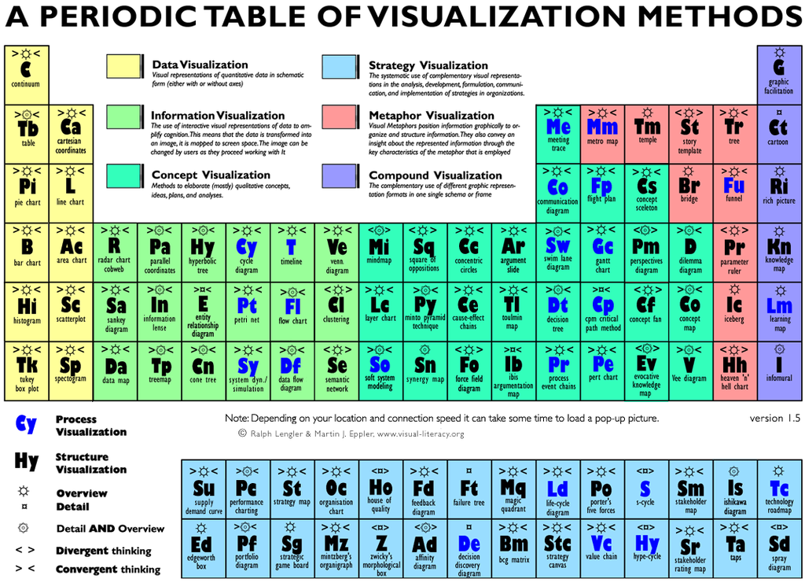